#My Reproducible Research Peer Assessment 1 #CM

##Loading and preprocessing the data

```r
getwd()
```

```
## [1] "C:/Users/Carolyn/Documents/R/Reproducible Research"
```

```r
setwd("C:/Users/Carolyn/Documents/R/Reproducible Research")
activity <- read.csv("activity.csv")

##Clean the data

activity$date <- as.Date(activity$date)
activity$interval <- as.factor(activity$interval)
```

##What is mean total number of steps taken per day.

##For this part of the assignment, you can ignore the missing values in the dataset.

```r
sum_data <- aggregate(activity$steps, by=list(activity$date), FUN=sum, na.rm=TRUE)
#Rename attributes
names(sum_data) <- c("date", "total")
```

##Make a histogram of the total number of steps take each day

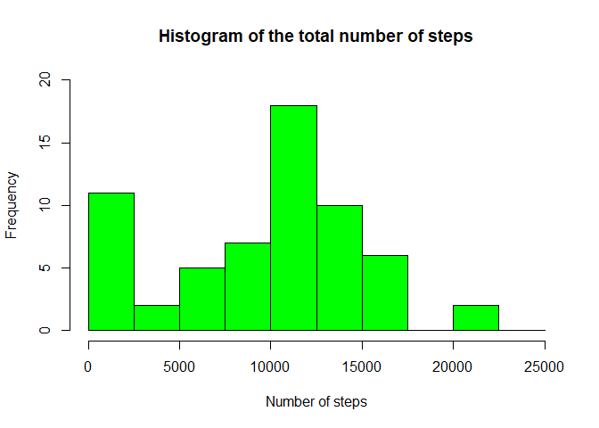

```r
hist(sum_data$total,
     breaks=seq(from=0, to=25000, by=2500),
     col="green",
     xlab="Number of steps",
     ylim=c(0, 20),
     main="Histogram of the total number of steps")
```

##Calculate and report the mean and median total number of steps taken per day

```r
mean(sum_data$total)
```

```
## [1] 9354.23
```

```r
median(sum_data$total)
```

```
## [1] 10395
```

##What is the average daily activity pattern?

#Clear the workspace rm(sum_data)

#Compute the mean of steps across intervals

```r
mean_data <- aggregate(activity$steps,
                       by=list(activity$interval),
                       FUN=mean,
                       na.rm=TRUE)
names(mean_data) <- c("interval", "mean")
head(mean_data)
```

```
##   interval      mean
## 1        0 1.7169811
## 2        5 0.3396226
## 3       10 0.1320755
## 4       15 0.1509434
## 5       20 0.0754717
## 6       25 2.0943396
```

#What is the average daily activity pattern?

#Make a time series plot

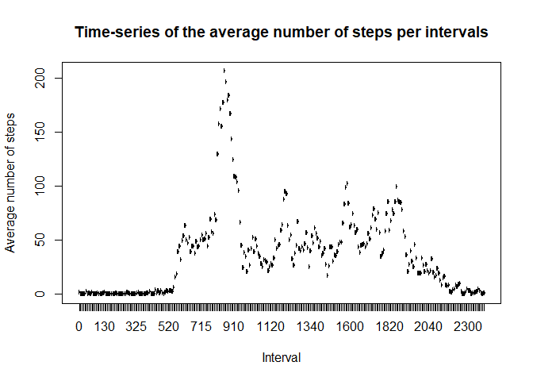

```r
plot(mean_data$interval,
     mean_data$mean,
     type="l",
     col="yellow",
     lwd=2,
     xlab="Interval",
     ylab="Average number of steps",
     main="Time-series of the average number of steps per intervals")
```

```r
max_pos <- which(mean_data$mean == max(mean_data$mean))
max_interval <- mean_data[max_pos, 1]
```

#Imputing missing values

#Clear workspace

```r
rm(max_interval)
#Boolean
NA_count <- sum(is.na(activity$steps))
```

##Devise a strategy for filling in all of the missing values in the dataset. The strategy does not need to be sophisticated. For example, you could use the mean/median for that day, or the mean for that 5-minute interval, etc.

#Find the NA’s

```r
na_pos <- which(is.na(activity$steps))
mean_vec <- rep(mean(activity$steps, na.rm=TRUE), times=length(na_pos))
```

#Create a new dataset that is equal to the original dataset but with the missing data filled in.

#Replace the NA’s by means

```r
activity[na_pos, "steps"] <- mean_vec
head(activity)
```

```
##     steps       date interval
## 1 37.3826 2012-10-01        0
## 2 37.3826 2012-10-01        5
## 3 37.3826 2012-10-01       10
## 4 37.3826 2012-10-01       15
## 5 37.3826 2012-10-01       20
## 6 37.3826 2012-10-01       25
```

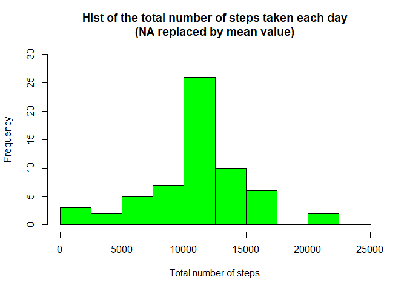

```r
sum_data <- aggregate(activity$steps, by=list(activity$date), FUN=sum)
names(sum_data) <- c("date", "total")
##Compute the histogram
hist(sum_data$total,
     breaks=seq(from=0, to=25000, by=2500),
     col="green",
     xlab="Total number of steps",
     ylim=c(0, 30),
     main="Hist of the total number of steps taken each day\n(NA replaced by mean value)")
```

Are there differences in activity patterns between weekdays and weekends?

#Function converting weekend to weekday

```r
wkday <- function(dat_val) {
  wd <- weekdays(as.Date(dat_val, '%Y-%m-%d'))
  if  (!(wd == 'Saturday' || wd == 'Sunday')) {
    x <- 'Weekday'
  }
  else {
    x <- 'Weekend'
  }
  x
}
#Factor weekend as weekday
activity$Day <- as.factor(sapply(activity$date, wkday))
```

#Compute the time series plot using ggplot2

```
## geom_path: Each group consists of only one observation. Do you need to adjust
## the group aesthetic?
## geom_path: Each group consists of only one observation. Do you need to adjust
## the group aesthetic?
```

[figure not shown]

```r
library(ggplot2)
#aggregate the mean steps
report_activity <- aggregate(steps~interval+Day,activity,mean)
#plot the data
g<- ggplot(report_activity, aes(interval,steps,activity))
g <-g+ geom_line(stat = 'identity', aes(color='Day')) + facet_grid(Day~.)
g+ labs(x= '5 mins Interval', y = "Average of Steps") + ggtitle("The dataset with “weekday” and “weekend”")
```